# MIS 381N - Project 1

Group 3 - Scroggings, Thelakkat, Tanwisuth, Wooten

February 13, 2018

```r
#Liabilities
l = c(12000,18000,20000,20000,16000,15000,12000,10000)

#Bond prices
p = c(102,99,101,98,98,104,100,101,102,94)

#Coupons
coupons = c(5,3.5,5,3.5,4,9,6,8,9,7)

#Maturities
m = c(1,2,2,3,4,5,5,6,7,8)
```

## Q1. Formulate portfolio construction problem as a linear program. Clearly list and describe the decision variables, the objective, and all the constraints.

Decision Variables: Amount of each of the 10 bonds i.e. x1,…,x10

Objective: Minimize the total cost of the bonds 102x1 + 99x2 + 101x3 + 98x4 + 98x5 + 104x6 + 100x7 + 101x8 + 102x9 + 94x10

Constraints: cash flow inward from coupon and maturity payments must equal cash flow outward to liabilities for each year (1-8)

```r
#Objective
c = p

#Constraints
A = matrix(0,length(l),length(c))
for (i in seq_along(coupons)){
  A[1:m[i]-1,i] = coupons[i]
  #Matrix with maturity and coupon payments
  A[m[i],i] = 100 + coupons[i]
}

#Direction
dir = rep("=",length(l))

#Constraints Vector
b = l
```

## Q2. Solving the test case

```r
#Solve LP
s = lp("min",c,A,dir,b)
sol = s$solution

#Optimal Solution
for (i in seq_along(sol)){
  cat("Bond",i,"\t:\t",sol[i],"\n")
}
```

```
## Bond 1   :    62.13613
## Bond 2   :    0
## Bond 3   :    125.2429
## Bond 4   :    151.5051
## Bond 5   :    156.8078
## Bond 6   :    123.0801
## Bond 7   :    0
## Bond 8   :    124.1573
## Bond 9   :    104.0899
## Bond 10  :    93.45794
```

## Q3. Writing the function

The dedicate_g3 function will construct a portfolio for any set of liabilities and bonds. The function takes four inputs: P, C, M, and L. P is the vector containing the prices of the bonds. C is the vector containing the coupon payments for the bonds. M is the vector containing the maturity (in years) for the bonds. Finally, L is the vector of non-negative liabilities for each year. The function outputs the optimal number of each bond to purchase to minimize price of bonds

```r
dedicate_g3 <- function(P,C,M,L){
  #Objective
  c = P

  #Constraints
  #Initialize constraints matrix with zeros
  A = matrix(0,length(L), length(C))

  for (i in seq_along(C)){
    A[1:M[i]-1,i] = C[i]

    #Matrix with maturity and final coupon payments
    A[M[i],i] = 100 + C[i]
  }

  #Direction
  dir = rep("=",length(L))

  #Constraints Vector
  b = L

  #Solution
  s = lp("min",c,A,dir,b,compute.sens=1)
  return(s)
}
```

Let’s test the function using our test case from problem 2.

```r
#Inputs
#Liabilities
l = c(12000,18000,20000,20000,16000,15000,12000,10000)

#Bond prices
p = c(102,99,101,98,98,104,100,101,102,94)

#Coupons
coup = c(5,3.5,5,3.5,4,9,6,8,9,7)

#Maturities
m = c(1,2,2,3,4,5,5,6,7,8)

#Calling the function
s = dedicate_g3(p,coup,m,l)
sol = s$solution

#Optimal Solution
for (i in seq_along(sol)){
  cat("Bond",i,"\t:\t",sol[i],"\n")
}
```

```
## Bond 1   :    62.13613
## Bond 2   :    0
## Bond 3   :    125.2429
## Bond 4   :    151.5051
## Bond 5   :    156.8078
## Bond 6   :    123.0801
## Bond 7   :    0
## Bond 8   :    124.1573
## Bond 9   :    104.0899
## Bond 10  :    93.45794
```

The results match!

## Q4. Construct a dedicated portfolio

Bond information was collected from the Wall Street Journal (http://online.wsj.com/mdc/public/page/2_3020-treasury.html#treasuryB) and stored as a csv file named “TreasuryQuotes_wsj.csv”.

```r
#Reading bond information
Bonds = read.csv("TreasuryQuotes_wsj.csv")
```

Create input vectors

```r
#Limit bonds to only those that mature/pay coupons at the end of June/December
dates = c("6/30/2017","12/31/2017","6/30/2018","12/31/2018","6/30/2019","12/31/2019","6/30/2020","12/31/2020","6/30/2021","12/31/2021","6/30/2022","12/31/2022")

Bonds = Bonds[Bonds$Maturity %in% dates,]

#Price Vector
P = Bonds$Asked

#Coupon Vector
C = Bonds$Coupon/2

#Maturities Vector (in periods/half-years)
#Assign each date to period number
periods = seq_along(dates)
names(periods) = dates

#Initialize maturities vector with zeros
M = rep(0,length(Bonds$Maturity))

#Add period number corresponding to each maturity date to maturities vector
for (i in seq_along(M)){
  date = toString(Bonds$Maturity[i])
  period = periods[date]

  M[i] = period
}

#Non-negative liabilities vector
L = 1000000*c(9,9,10,10,6,6,9,9,10,10,5,3)
```

Finally, we can solve for the optimal amount of each bond to purchase using the function we defined in Q3.

```r
options("scipen"=100, "digits"=4)
#Calling the function
s = dedicate_g3(P,C,M,L)

optimal_solution = data.frame(Bonds$Maturity,Bonds$Coupon,Bonds$Asked,s$solution)
names(optimal_solution) = c("Maturity","Coupon","Price","Amount to Purchase")
optimal_solution
```

```
##      Maturity Coupon  Price Amount to Purchase
## 1   6/30/2017  0.625 100.05                  0
## 2   6/30/2017  0.750 100.09                  0
## 3   6/30/2017  2.500 100.77              80607
## 4  12/31/2017  0.750  99.93                  0
## 5  12/31/2017  1.000 100.16                  0
## 6  12/31/2017  2.750 101.72              81615
## 7   6/30/2018  0.625  99.50                  0
## 8   6/30/2018  1.375 100.55                  0
## 9   6/30/2018  2.375 101.90              92737
## 10 12/31/2018  1.250 100.16                  0
## 11 12/31/2018  1.375 100.35              93838
## 12 12/31/2018  1.500 100.62                  0
## 13  6/30/2019  1.000  99.18                  0
## 14  6/30/2019  1.625 100.62              54484
## 15 12/31/2019  1.125  99.03                  0
## 16 12/31/2019  1.625 100.44              54926
## 17  6/30/2020  1.625 100.03              85372
## 18  6/30/2020  1.875 100.90                  0
## 19 12/31/2020  1.750 100.02                  0
## 20 12/31/2020  2.375 102.39              86066
## 21  6/30/2021  1.125  96.91                  0
## 22  6/30/2021  2.125 101.12              97088
## 23 12/31/2021  2.000 100.34                  0
## 24 12/31/2021  2.125 100.89              98120
## 25  6/30/2022  2.125 100.42              49162
## 26 12/31/2022  2.125  99.95              29685
```

### Sensitivity Analysis

Next we can evaluate the sensitivity of this model to the liability constraints.

```r
optimal_sol_sens = data.frame(dates,L,s$duals[0:length(L)],s$duals.from[0:length(L)],s$duals.to[0:length(L)])
names(optimal_sol_sens) = c("Date","Liability","Duals","Duals From","Duals To")

optimal_sol_sens
```

```
##          Date Liability  Duals Duals From                        Duals To
## 1   6/30/2017   9000000 0.9953     838507 1000000000000000019924668064446
## 2  12/31/2017   9000000 0.9899     726286                       610724618
## 3   6/30/2018  10000000 0.9837     616161                       715007482
## 4  12/31/2018  10000000 0.9764     551647                      1236112160
## 5   6/30/2019   6000000 0.9663     507379                      1051909041
## 6  12/31/2019   6000000 0.9567     462752                       687507465
## 7   6/30/2020   9000000 0.9450     393387                       696044713
## 8  12/31/2020   9000000 0.9319     291183                       484665463
## 9   6/30/2021  10000000 0.9192     188027                       547274633
## 10 12/31/2021  10000000 0.9072      83775                       552983176
## 11  6/30/2022   5000000 0.8930      31540                       553752372
## 12 12/31/2022   3000000 0.8789          0                       475588235
```

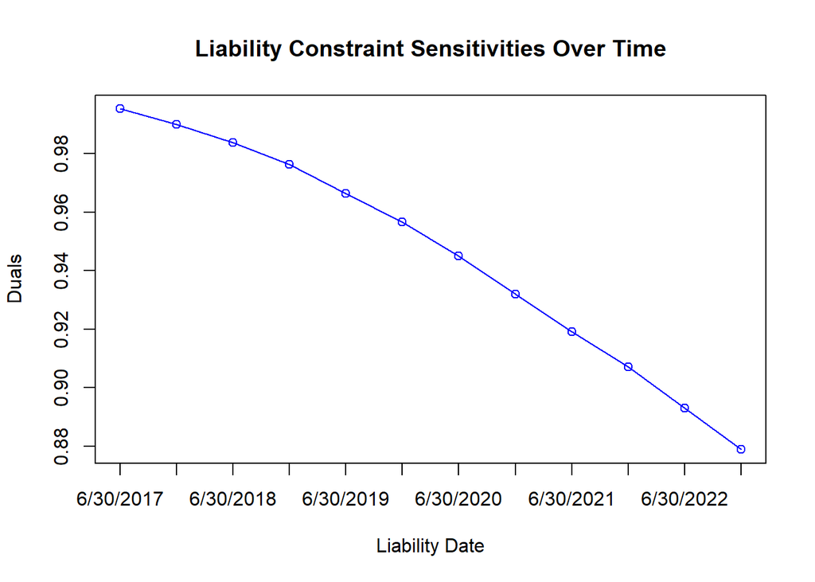

```r
plot(periods, optimal_sol_sens$Duals, main="Liability Constraint Sensitivities Over Time", xlab="Liability Date", ylab="Duals", type='o', col='blue', xaxt='n')
axis(1, at=1:12, labels=dates[1:12])
```

The duals (i.e. sensitivity of the constraint for each half-year) can be interperted as the time value of money. In other words, 1 dollar on 12/31/2022 is worth 88 cents today. The Duals From & To are the range of liabilities for that date for which the duals/sensitivity applies.